# HW14: Maps

Andrea Winingar

04 August 2020

Load packages

```r
library(here)
library(raster)
library(tidyverse)
library(ggthemes)
library(maptools)
library(ggmap)
```

### Part 1: Outline Maps

#### Example States and Countries

##### USA map

Unable to do at moment.

##### Missouri Map

unable to do at moment

#### Outline Maps: My Turn

Can’t do it.

### Part 2: Choropleth maps

#### Example: Skin cancer mortality in the U.S.

Import data

```r
skin_cancer_raw <-
  read_delim(file = here::here("data","skin_cancer.txt"),
             delim = " ",
             skip = 7,
             trim_ws = TRUE)
```

Wrangle the Data

Calculate mean skin cancer mortality rate. mean_mort for average of all 48 states. then use mutate() to add a relative_mort column, substracting the Mort column from the mean_mort average.

Create vector of lower 48 states.

Unable to do more of this portion.

#### Choropleth map: my turn

import data

| State | 2007 | 2008 | 2009 | 2010 | 2011 | 2012 | 2013 | 2014 | 2015 | 2016 | 2017_Confirmed | 2017_Probable |
| --- | --- | --- | --- | --- | --- | --- | --- | --- | --- | --- | --- | --- |
| Alabama | 13 | 6 | 3 | 1 | 9 | 13 | 11 | 28 | 14 | 17 | 25 | 16 |
| Alaska | 10 | 6 | 7 | 7 | 9 | 4 | 14 | 5 | 1 | 6 | 8 | 2 |
| Arizona | 2 | 2 | 3 | 2 | 8 | 7 | 22 | 14 | 8 | 8 | 18 | 10 |
| Arkansas | 1 | 0 | 0 | 0 | 0 | 0 | 0 | 0 | 0 | 0 | 2 | 4 |
| California | 75 | 74 | 117 | 126 | 79 | 61 | 90 | 54 | 83 | 90 | 84 | 61 |
| Colorado | 0 | 2 | 0 | 1 | 0 | 0 | 0 | 0 | 0 | 0 | 4 | 0 |
| Connecticut | 3058 | 2738 | 2751 | 1964 | 2004 | 1653 | 2111 | 1719 | 1873 | 1238 | 1381 | 670 |
| Delaware | 715 | 772 | 984 | 656 | 767 | 507 | 400 | 341 | 334 | 391 | 421 | 187 |
| District of Columbia | 116 | 71 | 53 | 34 | NA | NA | 33 | 35 | 78 | 66 | 62 | 22 |
| Florida | 30 | 72 | 77 | 56 | 78 | 67 | 87 | 85 | 116 | 132 | 124 | 86 |

[output cut: 41 more lines]

Create a new column called 2017 that adds together 2017_Confirmed and 2017_Probable, then remove the two columns.

```r
lyme_disease <- lyme_raw %>%
  mutate('2017' = 2017_Confirmed + 2017_Probable)
```

```
Error: unexpected input in:
"lyme_disease <- lyme_raw %>%
  mutate('2017' = 2017_"
```

Can’t do anymore.

### Part 3: Dot distribution maps

#### Example: Distribution of Gigantopithecus and Ursus

Define global vars, then use setseed()

Load bigfoot data, filter data, sample 300, change genus, then select name, long, lat

```r
bigfoot <- read_csv(here::here("data", "bigfoot.csv"))
```

import bears data.

| name | long | lat |
| --- | --- | --- |
| Ursus americanus | -125.7660 | 49.18350 |
| Ursus americanus | -110.4483 | 44.94100 |
| Ursus americanus | -118.6961 | 34.94750 |
| Ursus americanus | -113.5683 | 34.60667 |
| Ursus americanus | -122.9068 | 43.41780 |
| Ursus americanus | -124.8627 | 49.87958 |

Map

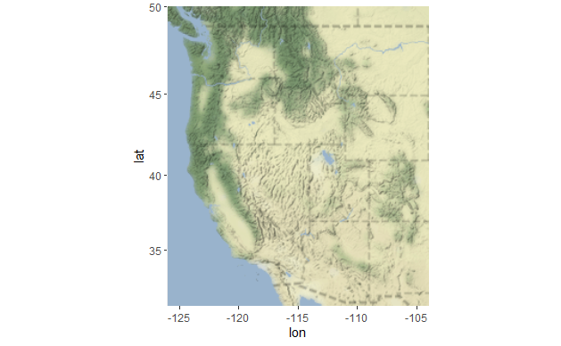

ggmap uses ggplot2 to plot this layer, so we can store the result into an object and add to it using familiar geoms. The first layer to add is the Bigfoot data.

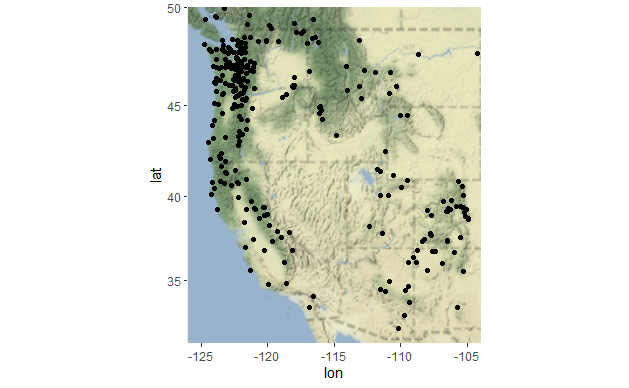

Black Bears

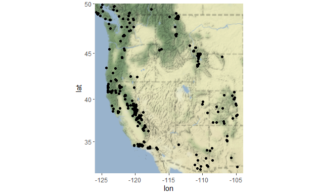

Both species

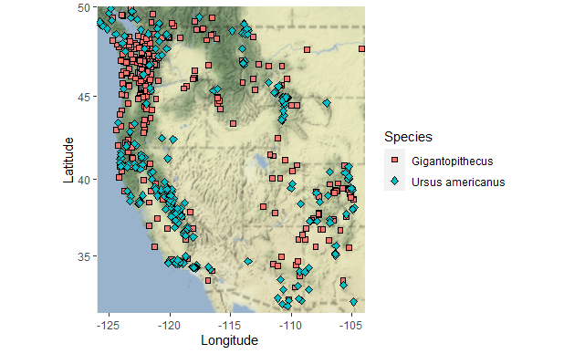

#### Distribution map: your turn

Recreate the Bigfoot and Black Bear distribution map but change the setseed number to your last seven digits of your S0 number. The seed determines the random sample of Bigfoot sightings but the bear distribution should not change.

change set.seed()

recreate nigffot data for bigfoot 2

```r
bigfoot2 <- read_csv(here::here("data", "bigfoot.csv"))
```

Same for bears2, then combine species to bot species_2

| name | long | lat |
| --- | --- | --- |
| Ursus americanus | -125.7660 | 49.18350 |
| Ursus americanus | -110.4483 | 44.94100 |
| Ursus americanus | -118.6961 | 34.94750 |
| Ursus americanus | -113.5683 | 34.60667 |
| Ursus americanus | -122.9068 | 43.41780 |
| Ursus americanus | -124.8627 | 49.87958 |

Map 2

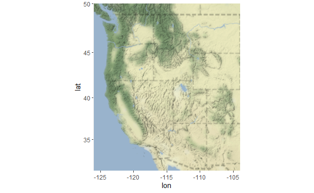

Bigfoot map 2

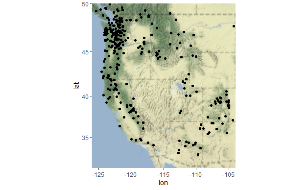

Bear map 2

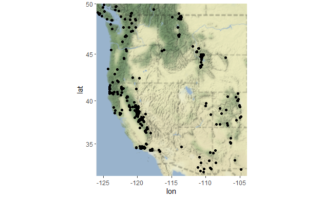

Both map 2

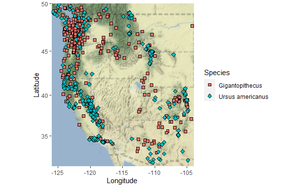

### Part 4: Bathymetry

#### Example: Fiji earthquakes

Define global variable range, convert depth to feet.

```r
min_long <- -170
max_long <- 164
min_lat  <- -42
max_lat  <- -8
earthquakes <- quakes %>%
   mutate(depth = depth * 3280.84)
```

can’t do anymore.

#### Bathymetry: now you try it

GLobal Variables, load blennies

```r
blennies_raw <- read_csv(here('data', 'blennies.csv'))
```